# R - Animation

#### Simple Exponential Smoothing

```r
se_model <- ses(dat_ts, h = (5*12))
summary(se_model)
```

```
##
## Forecast method: Simple exponential smoothing
##
## Model Information:
## Simple exponential smoothing
##
## Call:
##  ses(y = dat_ts, h = (5 * 12))
##
##   Smoothing parameters:
##     alpha = 0.4732
##
##   Initial states:
##     l = -0.8637
##
##   sigma:  0.1118
##
##      AIC     AICc      BIC
## 4973.578 4973.593 4989.793
##
## Error measures:
##                       ME      RMSE        MAE MPE MAPE      MASE       ACF1
## Training set 0.001432977 0.1117352 0.08778334 NaN  Inf 0.6071985 0.06050552
##
## Forecasts:
##          Point Forecast        Lo 80     Hi 80        Lo 95     Hi 95
## Jan 2017      0.2511472  0.107865511 0.3944288  0.032016785 0.4702775
## Feb 2017      0.2511472  0.092630691 0.4096636  0.008717138 0.4935772
## Mar 2017      0.2511472  0.078736862 0.4235575 -0.012531640 0.5148260
## Apr 2017      0.2511472  0.065882077 0.4364123 -0.032191337 0.5344857
## May 2017      0.2511472  0.053863123 0.4484312 -0.050572740 0.5528671
## Jun 2017      0.2511472  0.042535484 0.4597588 -0.067896869 0.5701912
## Jul 2017      0.2511472  0.031792034 0.4705023 -0.084327559 0.5866219
## Aug 2017      0.2511472  0.021550750 0.4807436 -0.099990251 0.6022846
## Sep 2017      0.2511472  0.011747178 0.4905472 -0.114983521 0.6172779
## Oct 2017      0.2511472  0.002329573 0.4999648 -0.129386505 0.6316808
## Nov 2017      0.2511472 -0.006744352 0.5090387 -0.143263875 0.6455582
## Dec 2017      0.2511472 -0.015509683 0.5178040 -0.156669292 0.6589636
## Jan 2018      0.2511472 -0.023995916 0.5262902 -0.169647865 0.6719422
## Feb 2018      0.2511472 -0.032228125 0.5345225 -0.182237943 0.6845323
```

[output cut: 31 more lines]

```
## Oct 2020      0.2511472 -0.225751611 0.7280459 -0.478206573 0.9805009
## Nov 2020      0.2511472 -0.230548052 0.7328424 -0.485542098 0.9878364
## Dec 2020      0.2511472 -0.235297202 0.7375915 -0.492805296 0.9950996
## Jan 2021      0.2511472 -0.240000433 0.7422948 -0.499998266 1.0022926
## Feb 2021      0.2511472 -0.244659050 0.7469534 -0.507123007 1.0094173
## Mar 2021      0.2511472 -0.249274301 0.7515686 -0.514181423 1.0164758
## Apr 2021      0.2511472 -0.253847373 0.7561417 -0.521175334 1.0234697
## May 2021      0.2511472 -0.258379403 0.7606737 -0.528106476 1.0304008
## Jun 2021      0.2511472 -0.262871477 0.7651658 -0.534976509 1.0372708
## Jul 2021      0.2511472 -0.267324632 0.7696190 -0.541787023 1.0440814
## Aug 2021      0.2511472 -0.271739863 0.7740342 -0.548539536 1.0508339
## Sep 2021      0.2511472 -0.276118124 0.7784125 -0.555235508 1.0575298
## Oct 2021      0.2511472 -0.280460326 0.7827547 -0.561876334 1.0641707
## Nov 2021      0.2511472 -0.284767348 0.7870617 -0.568463355 1.0707577
## Dec 2021      0.2511472 -0.289040030 0.7913344 -0.574997858 1.0772922
```

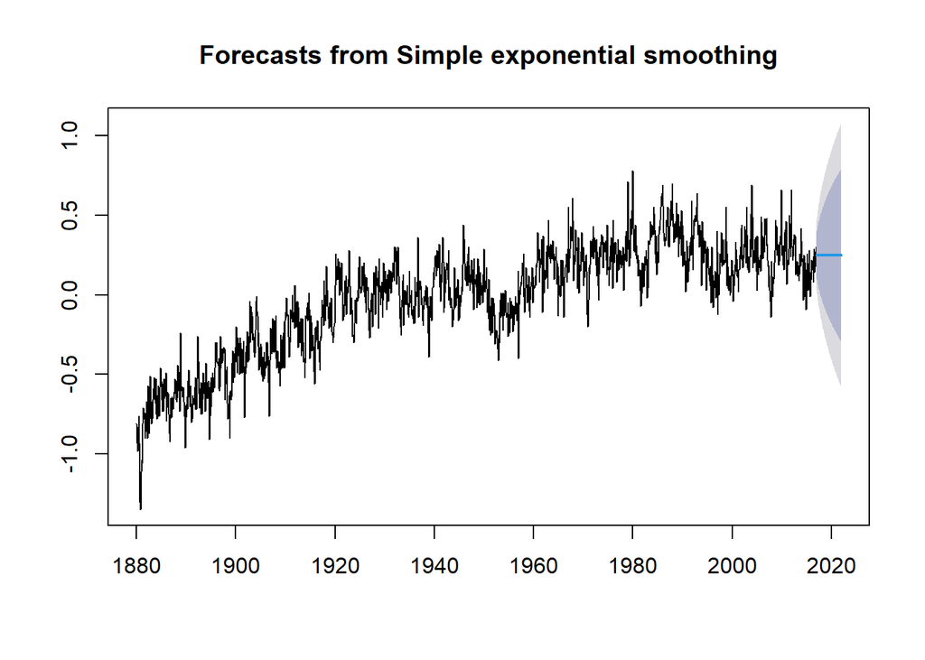

```r
plot(se_model)
```

### ARIMA

ARIMA (Autoregressive Integrated Moving Average) modeling is one of the most widely used approaches for time series forecasting. While exponential smoothing models focus on describing trends and seasonality in the data, ARIMA models aim to capture the autocorrelations or dependencies within the data.

The auto.arima() function is a tool that attempts to model the temporal trend in a time series. It automatically identifies and selects an appropriate ARIMA model by analyzing the autocorrelations and differences in the data. This automation makes it a convenient choice for time series analysis, especially when you have limited prior knowledge about the data’s underlying structure.

```r
arima_model <- auto.arima(dat_ts)
summary(arima_model)
```

```
## Series: dat_ts
## ARIMA(3,1,2)(0,0,2)[12] with drift
##
## Coefficients:
##          ar1      ar2      ar3      ma1     ma2    sma1    sma2  drift
##       1.0504  -0.1179  -0.0269  -1.5595  0.5669  0.0534  0.1059  6e-04
## s.e.  0.1087   0.0598   0.0389   0.1055  0.1033  0.0255  0.0235  3e-04
##
## sigma^2 = 0.0118:  log likelihood = 1319.11
## AIC=-2620.22   AICc=-2620.11   BIC=-2571.58
##
## Training set error measures:
##                        ME      RMSE        MAE MPE MAPE      MASE         ACF1
## Training set 0.0003813179 0.1083357 0.08432446 NaN  Inf 0.5832733 0.0007474847
```

Th actual data (red), and the fitted model can be visualized to show how well it does at measuring the temporal variability

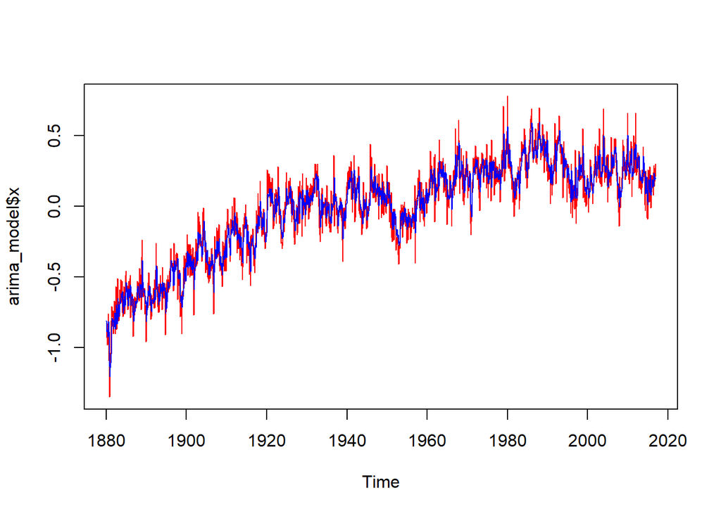

```r
plot(arima_model$x,col="red")
lines(fitted(arima_model),col="blue")
```

We can similarly use the ARIMA model to forecast global temperature anomalies using the forecast() function.Please note that real-world forecasting often involves more in-depth data preparation and model tuning to ensure the accuracy of predictions, and it’s crucial to use relevant historical temperature anomaly data to develop a reliable ARIMA model.

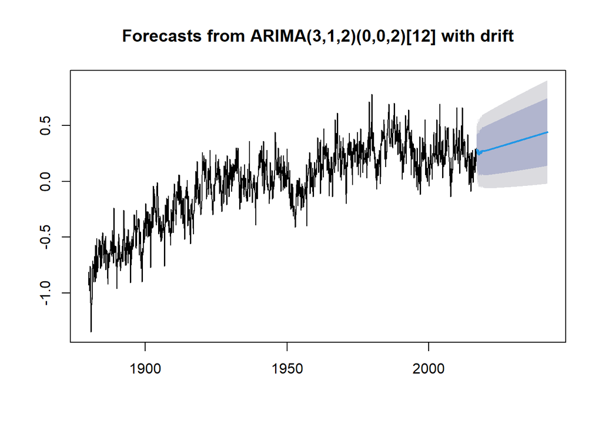

```r
fore_arima = forecast::forecast(arima_model, h=(25*12))
plot(fore_arima)
```

## Assignment

1. Conduct a comprehensive exploration of the spatiotemporal nuances within the provided social media dataset. This could, for example, investigate the underlying factors contributing to the observed differences between nature and non-nature photographs, or analyze the temporal and geographic variations that might account for specific trends in photograph sharing. You are expected to employ advanced statistical and geospatial techniques to delve deeper into this phenomenon. To substantiate your findings, create compelling visual representations that effectively illustrate the spatiotemporal dynamics at play. Provide a robust argument based on your analytical insights.
2. Social media data include various sources of noise related to the frequency of sharing photographs that can obscure meaningful patterns. Your task is to develop a technique for noise reduction that surpasses basic filtering methods. Additionally, generate a visually engaging GIF that elucidates the spatiotemporal dynamics within the data. Alongside this, propose a hypothesis that elucidates the observed patterns based on your knowledge of the region and geographic processes. Your hypothesis should reflect your understanding of the factors of social media sharing and how they influence the temporal and spatial aspects of photograph sharing.